# Machine Learning Prediction Project

Alejandro Morales Gallardo

September 19, 2014

# Summary

# Analysis

```r
library(caret); library(randomForest)
```

```r
trainData <- read.csv("../pml-training.csv",na.strings=c("","NA"))
testData <- read.csv("../pml-testing.csv")
```

## Pre-processing

The dimensions of the training data are

```
## [1] 19622   160
```

Since the number of variables is considerably large, preprocessing of the original training data is needed in order to simplify our analysis and possibly speed up any prediction algorithm to be used. After a brief exploratory data analysis, we find that as many as $100$ variables have well over $97$% of missing values and we readily discard those variables as predictors,

```r
na.ind <-as.vector(which(colSums(is.na(trainData))>10000,arr.ind=T))
length(na.ind)
```

```
## [1] 100
```

As an example, I show a summary of the variable *max_roll_belt*.

```r
summary(trainData[,18])
```

```
##    Min. 1st Qu.  Median    Mean 3rd Qu.    Max.    NA's
##     -94     -88      -5      -7      18     180   19216
```

Furthermore, it seems plausible that the name of the participants and the time variables are not needed for the analysis. The window variables (*new_window*,*num_window*) appear not to be relevant to our analysis as well. We therefore discard the first 7 variables, namely,

```r
other.ind <- 1:7
names(trainData)[1:7]
```

```
## [1] "X"                    "user_name"            "raw_timestamp_part_1"
## [4] "raw_timestamp_part_2" "cvtd_timestamp"       "new_window"
## [7] "num_window"
```

After the initial pre-processing we are left with a training data set containing 53 variables.

```r
#preprocessed datasets with reduced variables
exclude.ind <- c(other.ind,na.ind); exclude.ind<- exclude.ind[order(exclude.ind)]
training2 <- trainData[,-exclude.ind]
testing2 <- testData[,-exclude.ind]
```

## Data Partition

We split the training dataset (denoted by the variable trainData) into a training and testing datasets using the *createDataPartition* function from the caret package. We split the data, assigning 70% of the trainData observations in the training set to be used in our analysis and assign the reminder 30% to the testing set as our cross-validation dataset. For reproducibility purposes, we set a seed number.

```r
# set seed
set.seed(3232)
# Partition training set into training/testing
inTrain <- createDataPartition(y = training2$classe, p = .7, list = FALSE)
training <- training2[inTrain,]
testing <- training2[-inTrain,]
```

## Further pre-processing

Many of the variables are not normal and are rather skewed as we can confirm in the following histogram,

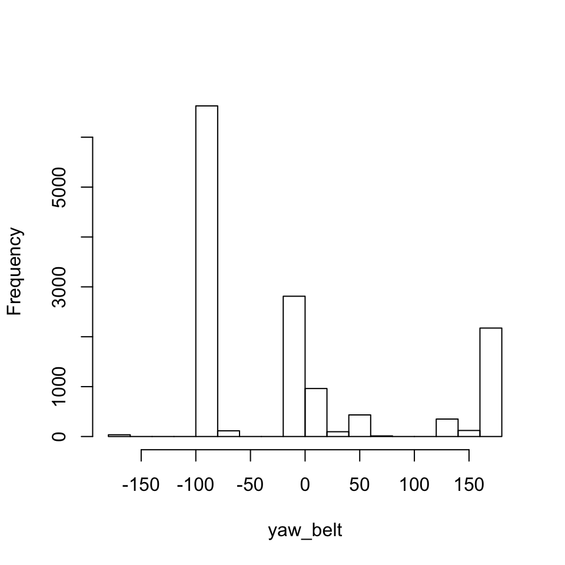

We therefore preform further preprocessing of the data using the caret package. The data is standardized and also principal component analysis is done to further reduce the number of useful predictors.

```r
preObj <- preProcess(training[,-53],method=c("center","scale","pca"))
```

```r
trainPC <- predict(preObj,training[,-53])
#modelFit <- train(training$classe~., data=trainPC, method="rf")
```

We then apply the preprocessed of the training set to the testing set,

```r
testPC <- predict(preObj,testing[,-53])
#confusion<-confusionMatrix(testing$classe,predict(modelFit,testPC))
#conf
```

```r
#predicting values random forest
#pred <- predict(modelFit,testPC); testing$predRight <- pred==testing$classe
#table1<-table(testing$classe,pred)
#table1
```

```r
#rf estimated error
```

In general cross-validation is not needed as random forest is a bootstrapping method with multiple samples

```r
#conf$overall[1][1]
```

# References

[1] Velloso, E.; Bulling, A.; Gellersen, H.; Ugulino, W.; Fuks, H. Qualitative Activity Recognition of Weight Lifting Exercises. Proceedings of 4th International Conference in Cooperation with SIGCHI (Augmented Human ’13) . Stuttgart, Germany: ACM SIGCHI, 2013.